# Etude de la base de données Agribalyse : alimentation et changement climatique

```r
library(tidyverse) ## pour la mise en forme des données
library(readxl) ## lecture des données au format excel
# library(plyr)

url1<-'https://data.ademe.fr/data-fair/api/v1/datasets/agribalyse-31-synthese/metadata-attachments/AGRIBALYSE3.1.1_produits%20alimentaires.xlsx'
p1f <- tempfile()

download.file(url1, p1f, mode="wb")
agri <- read_excel(path=p1f , sheet = 2, col_names = TRUE, na = "", skip =2)
dim(agri)
```

```
## [1] 2518   29
```

```r
head(agri)
```

```
## # A tibble: 6 × 29
##   `Code\r\nAGB` `Code\r\nCIQUAL` `Groupe d'aliment`       Sous-groupe d'alimen…¹
##   <chr>         <chr>            <chr>                    <chr>
## 1 11084         11084            aides culinaires et ing… algues
## 2 11023         11023            aides culinaires et ing… herbes
## 3 11000         11000            aides culinaires et ing… herbes
## 4 11093         11093            aides culinaires et ing… herbes
## 5 20995         20995            aides culinaires et ing… algues
## 6 20998         20998            aides culinaires et ing… algues
## # ℹ abbreviated name: ¹`Sous-groupe d'aliment`
## # ℹ 25 more variables: `Nom du Produit en Français` <chr>, `LCI Name` <chr>,
## #   `code saison (0 : hors saison ; 1 : de saison ; 2 : mix de consommation FR)` <dbl>,
## #   `code avion (1 : par avion)` <dbl>, Livraison <chr>,
## #   `Matériau d'emballage` <chr>, Préparation <chr>,
## #   `DQR - Note de qualité de la donnée (1 excellente ; 5 très faible)` <dbl>,
## #   `mPt/kg de produit` <dbl>, `kg CO2 eq/kg de produit` <dbl>, …
```

```r
##  Récupération des  noms des variables qui se trouvent sur plusieurs lignes

pour_nom <- read_excel(path=p1f , sheet = 2, col_names = TRUE, na = "", skip =1)
#colnames(pour_nom)
colnames(agri)[!grepl("\\.\\.\\.",colnames(pour_nom))] <- colnames(pour_nom)[!grepl("\\.\\.\\.",colnames(pour_nom))]
dim(agri)
```

```
## [1] 2518   29
```

```r
agri_detail_nom  <- read_excel(path=p1f , sheet = 3, col_names = TRUE, na = "", skip =0)
agri_detail <-read_excel(path=p1f , sheet = 3, col_names = TRUE, na = "", skip =2)
colnames(agri)[1] <- "Code AGB"

agri_all_indic <- agri[,13:29]

## agri changement climatique :
## probleme de sauce au poivre 11212 !
#  max(table(agri_detail[,1]))
# sum(table(agri_detail[,1])==2)
agri_detail$`Code AGB`[agri_detail$`Code CIQUAL`=="11212"] <- "11212"

agri_cc <- full_join(agri[,-c(13:29)], agri_detail[,c(1,16:22)])

colnames(agri_cc) <- gsub("\\.\\.\\.[0-9][0-9]","", colnames(agri_cc))

dim(agri_cc)
```

```
## [1] 2518   19
```

```r
head(agri_cc)
```

```
## # A tibble: 6 × 19
##   `Code AGB` `Code\r\nCIQUAL` Synthèse                    Sous-groupe d'alimen…¹
##   <chr>      <chr>            <chr>                       <chr>
## 1 11084      11084            aides culinaires et ingréd… algues
## 2 11023      11023            aides culinaires et ingréd… herbes
## 3 11000      11000            aides culinaires et ingréd… herbes
## 4 11093      11093            aides culinaires et ingréd… herbes
## 5 20995      20995            aides culinaires et ingréd… algues
## 6 20998      20998            aides culinaires et ingréd… algues
## # ℹ abbreviated name: ¹`Sous-groupe d'aliment`
## # ℹ 15 more variables: `Nom du Produit en Français` <chr>, `LCI Name` <chr>,
## #   `code saison (0 : hors saison ; 1 : de saison ; 2 : mix de consommation FR)` <dbl>,
## #   `code avion (1 : par avion)` <dbl>, Livraison <chr>,
## #   `Matériau d'emballage` <chr>, Préparation <chr>,
## #   `DQR - Note de qualité de la donnée (1 excellente ; 5 très faible)` <dbl>,
## #   Agriculture <dbl>, Transformation <dbl>, Emballage <dbl>, …
```

```r
### changement des noms de quelques modalités pour des raisons cosmétiques
agri_cc$`Synthèse`<-plyr::revalue(agri_cc$`Synthèse`,c("viandes, œufs, poissons"="viandes, oeufs, poissons"))
agri_cc$`Synthèse`<-plyr::revalue(agri_cc$`Synthèse`,c("fruits, légumes, légumineuses et oléagineux"="fruits et légumes"))
agri_cc$`Synthèse`<-plyr::revalue(agri_cc$`Synthèse`,c("aides culinaires et ingrédients divers"="aides culinaires"))
agri_cc$`Sous-groupe d'aliment`<-plyr::revalue(agri_cc$`Sous-groupe d'aliment`,c("œufs"="oeufs"))
agri_cc$`Sous-groupe d'aliment`<-plyr::revalue(agri_cc$`Sous-groupe d'aliment`,c("produits à base de poissons et produits de la mer"="produits à base de poisson"))
```

### Lien entre le type d’aliment et les émissions de C02

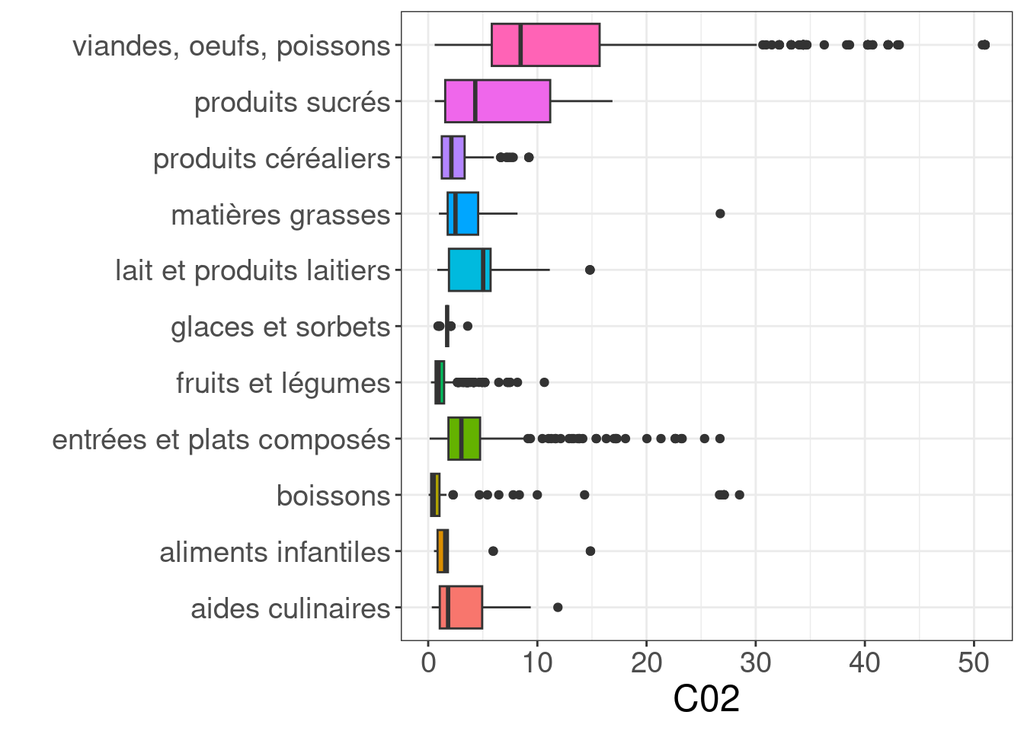

Une première étude descriptive met en évidence que le total des émissions en C02 est le plus important pour les viandes, oeufs et poissons (à la fois la valeur médiane et les valeurs extrêmes), puis pour les produits sucrés. Les groupes pour lesquels les émissions sont les plus faibles sont les glaces et sorbets, les fruits et légumes; les boissons (malgré quelques valeurs extêmes) et les aliments infantiles.

2. En mettant une couleur par sous-groupe d’aliment, on voit que le sous-groupe a l’air d’avoir une importance, notamment quand on regarde le groupe “viandes, oeufs, poissons” et “produits sucrés”, ce qui suggère qu’il serait intéressant de faire la même analyse à l’échelle du sous-groupe.

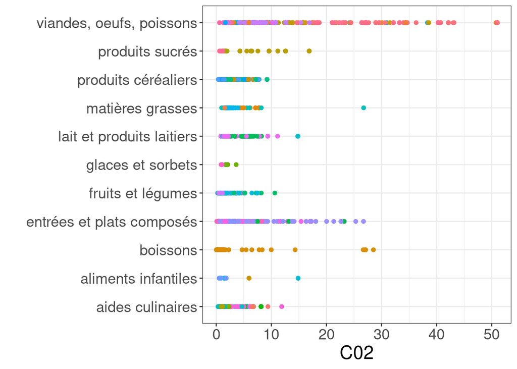

3. On voit une grande variabilité au sein du groupe “viandes, oeufs et poisson”, ainsi que dans le groupe des produits sucrés. Pour ces deux groupes, nous allons donc regarder plus en détail à l’échelle du sous-groupe.

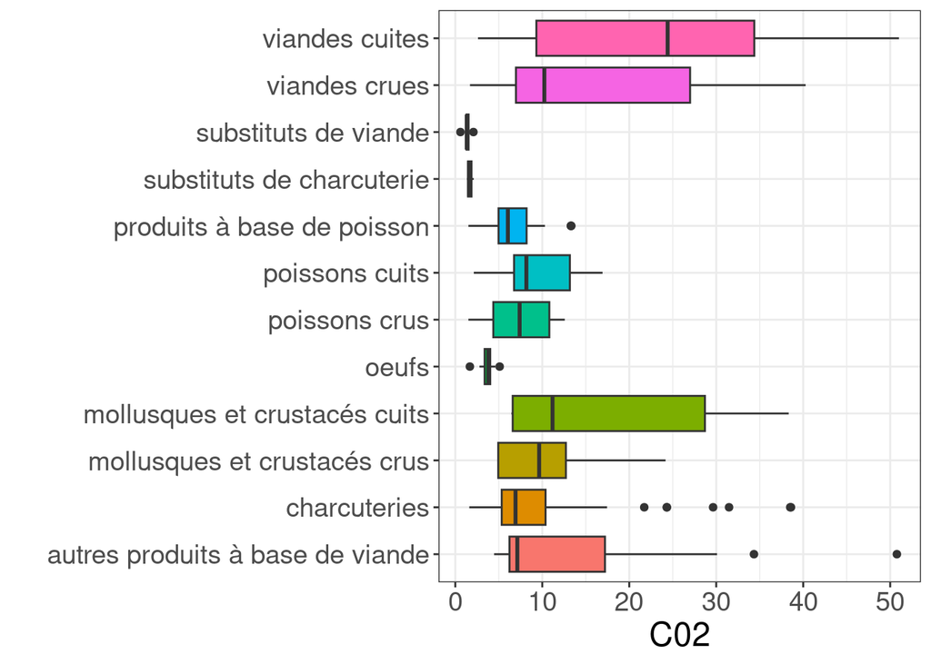

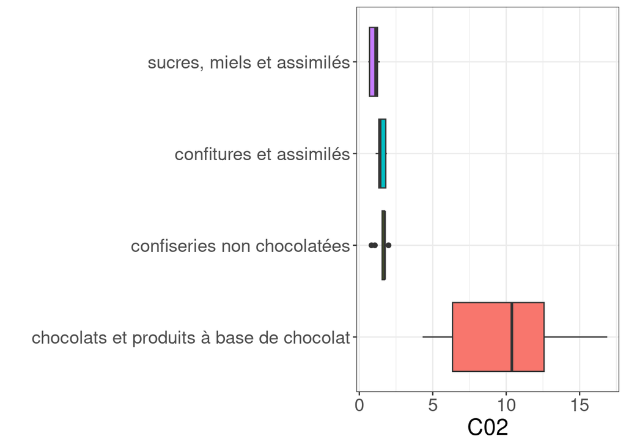

A l’échelle des sous-groupes de la catégorie “viandes, poissons et oeufs”, on voit que ce sont les viandes crues et cuites qui émettent le plus de C02. Encore une fois, on observe une variabililté importante au sein de ces groupes. Au sein de la catégorie “produits sucrés”, on voit que les émissions de C02 sont largement supérieures pour les produits à base de chocolat.

4. Afin d’étudier plus en détail le type de viande, on crée un nouveau tableau qui contient uniquement les aliments de type “viande crue” ou “viande cuite”, puis on crée une nouvelle variable qui associe le type précis de viande.

```r
viande <- agri_cc %>%
filter(`Sous-groupe d'aliment` %in% c("viandes crues","viandes cuites")) %>%
mutate(Type_viande = case_when(
grepl("Agneau",`Nom du Produit en Français`,ignore.case=TRUE)~"Agneau",
grepl("Boeuf",`Nom du Produit en Français`,ignore.case=TRUE) ~"Boeuf",
grepl("Bœuf",`Nom du Produit en Français`,ignore.case=TRUE) ~"Boeuf",
grepl("Porc",`Nom du Produit en Français`,ignore.case=TRUE)~"Porc",
grepl("Canard",`Nom du Produit en Français`,ignore.case=TRUE)~"Canard",
grepl("Poulet",`Nom du Produit en Français`,ignore.case=TRUE)~"Poulet",
grepl("Dinde",`Nom du Produit en Français`,ignore.case=TRUE)~"Dinde",
grepl("Veau",`Nom du Produit en Français`,ignore.case=TRUE)~"Veau",
grepl("Lapin",`Nom du Produit en Français`,ignore.case=TRUE)~"Lapin",
grepl("Mouton",`Nom du Produit en Français`,ignore.case=TRUE)~"Mouton",
TRUE~"other"
))

head(viande$Type_viande)
```

```
## [1] "Agneau" "Agneau" "Agneau" "Agneau" "Agneau" "Agneau"
```

```r
table(viande$Type_viande)
```

```
##
## Agneau  Boeuf Canard  Dinde  Lapin Mouton  other   Porc Poulet   Veau
##     29     56      8     13      6      5     21     42     25     36
```

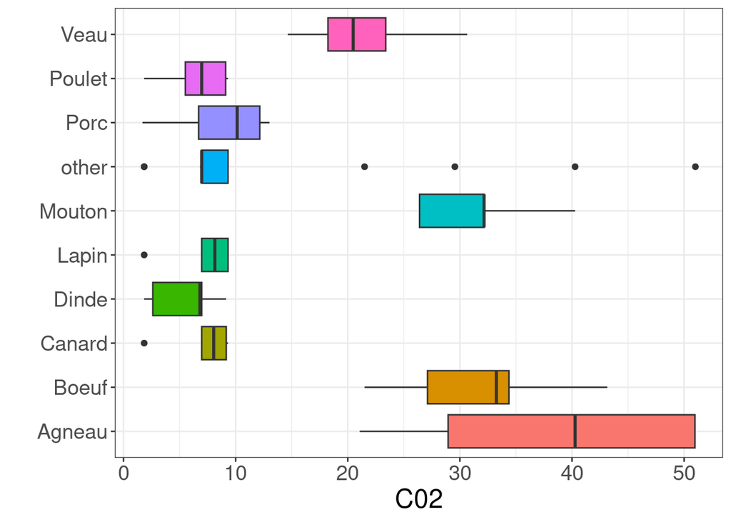

```r
viande %>%
  ggplot(aes(y =Total , x = Type_viande,fill=Type_viande)) + geom_boxplot() + coord_flip() +
  guides(fill=FALSE)+
  labs(y=" C02 ")+labs(x=" ")
```

5. On voit finalement que les émissions dépendent beaucoup du type de viande : l’agneau ou le boeuf émettent beaucoup plus de $\textrm{C0}_2$ que le poulet, le porc, la dinde, le lapin ou le canard. La variabilité reste cependant très importante même pour un seul type de viande ! Une explication probable est que l’on ne prend pas en compte le type d’élevage (intensif, extensif…), la provenance (produit local ou non) etc.

### Emissions de $\textrm{C0}_2$ par étape du processus de commercialisation d’un produit

6. On regarde les émissions de $\textrm{C0}_2$ attribuées à chaque étape.

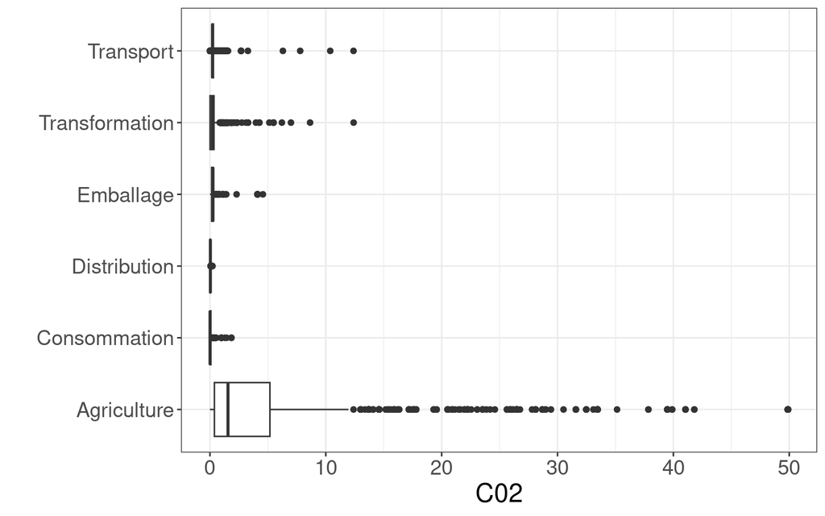

On voit que c’est de loin l’agriculture qui est responsable de la plus grande part de C02.

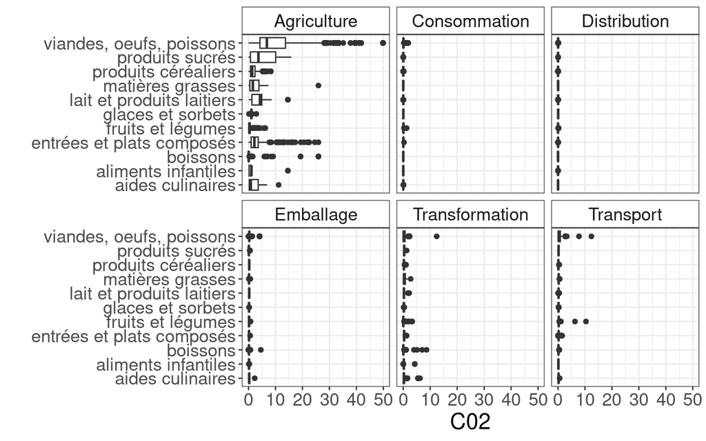

En affichant une couleur par sous-groupe, on voit une fois de plus qu’il pourrait être pertinent de regarder les impacts à l’échelle du sous-groupe.

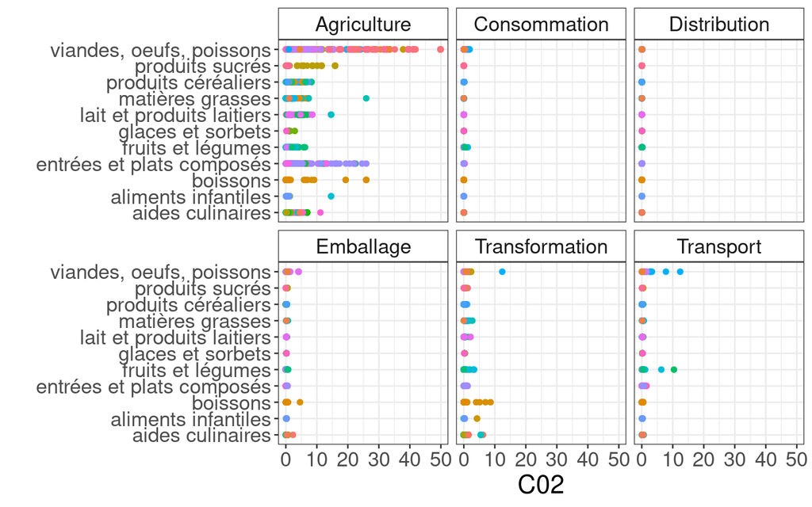

```
## # A tibble: 20 × 3
##    Transport `Sous-groupe d'aliment`       `Nom du Produit en Français`
##        <dbl> <chr>                         <chr>
##  1     12.4  mollusques et crustacés cuits Homard, bouilli/cuit à l'eau
##  2     10.4  fruits                        Mangue importée par avion, pulpe, cr…
##  3      7.79 mollusques et crustacés crus  Langoustine, crue
##  4      6.30 légumes                       Haricot vert importé par avion, cru
##  5      3.27 mollusques et crustacés cuits Coquille Saint-Jacques, noix et cora…
##  6      2.69 mollusques et crustacés crus  Coquille Saint-Jacques, noix et cora…
##  7      2.69 mollusques et crustacés crus  Coquille Saint-Jacques, noix, crue
##  8      2.69 mollusques et crustacés crus  Pecten d'Amérique ou Peigne du canad…
##  9      2.69 mollusques et crustacés crus  Pétoncle ou Peigne du Pérou, noix, c…
## 10      1.56 salades composées et crudités Salade composée avec viande ou poiss…
## 11      1.49 produits à base de poisson    Maquereau, filet au vin blanc, apper…
## 12      1.49 produits à base de poisson    Maquereau, filet sauce moutarde, app…
## 13      1.49 produits à base de poisson    Maquereau, filet sauce tomate, apper…
## 14      1.49 produits à base de poisson    Maquereau, au naturel, appertisé, ég…
## 15      1.44 plats composés                Brochette de poisson
## 16      1.43 produits à base de poisson    Carrelet ou plie, pané, frit
## 17      1.43 poissons cuits                Églefin, grillé/poêlé
## 18      1.43 produits à base de poisson    Limande-sole, panée, frite
## 19      1.43 poissons cuits                Merlan, frit
## 20      1.43 poissons cuits                Cabillaud, cuit à la vapeur
```